# Practical Implementations of Principal Component Analysis

Author

Shivani

Published

August 7, 2024

View Slideshow

## Introduction

Principal Component Analysis (PCA) is a pivotal multivariate data analysis technique employed to simplify complex datasets by reducing their dimensionality while retaining critical information. PCA has become an essential tool in statistical analysis and data science for its ability to identify patterns and relationships within high-dimensional data (Jauregui 2017).

PCA leverages the mathematical framework of linear algebra, specifically the eigen-decomposition of covariance or correlation matrices, to transform a set of possibly correlated variables into a smaller number of uncorrelated variables known as principal components.

This transformation is achieved by identifying the eigenvectors and eigenvalues of the matrix, where eigenvectors define the directions of maximum variance and eigenvalues indicate the magnitude of variance along these directions. (Sidharth Prasad 2017).

## Related work

The development of Principal Component Analysis (PCA) can be traced back to the foundational work of Pearson (1901), who introduced the concept of reducing dimensionality in multivariate datasets by identifying linear projections that maximize variance (Bro and Smilde 2014).

## Methods

While different methods can be used to determine the principal components, Singular Value Decomposition (SVD) is the most common due to its computational efficiency and numerical stability. SVD decomposes the data into three simpler matrices, making it possible to handle large datasets effectively. This decomposition allows for a more straightforward calculation of the principal components without explicitly computing the covariance matrix, which can be computationally expensive and numerically unstable. The ability to handle sparse and dense matrices further enhances its versatility and efficiency in diverse applications. These advantages make SVD a preferred method in popular programming packages, ensuring that PCA is performed quickly and accurately (Johnson and Wichern 2023).

### Overview of Algorithm with SVD:

1. **Standardize the data**
   Ensure each variable contributes equally by having a mean of zero and variance of one. This requires that the variables are continuous.
   $$X_\text{standardized} = \frac{X - \mu}{\sigma}$$
   $\mu$: mean, $\sigma$: standard deviation of each variable
2. **Perform Singular Value Decomposition (SVD)**
   Decompose the standardized data matrix into three matrices $U$, $\Sigma$, and $V^T$.
   $$X_\text{standardized} = U \Sigma V^T$$
   $𝑈$ and $V^T$ are orthogonal matrices, so therefore $U$ and $V$ are also orthogonal. The diagonal matrix of singular values is represented by $\sigma$ with values $\sigma_i$ that are naturally sorted in descending order. Each column of $𝑉$ represents a principal component (PC) which are orthogonal to each other in the transformed feature space. The number of PC’s initially generated are equivalent to the number of variables initially provided in the dataset.
3. **Selection of principal components**
   The explained variance of each PC is represented by:
   $$\text{variance explained} = \frac{\sigma_i^2}{\sum \sigma_i^2}$$
   For each singular value $\sigma_i$ in the matrix of singular values $\Sigma$, compute $\sigma_i^2$ and calculate the individual variance. The cumulative explained variance target is specified (typically 95%) as a criteria for PC selection. Determine the number of components needs to reach the desired cumulative explained variance.
4. **Transform the data**
   Project the data onto the selected principal components. This yields the new subspace with reduced dimensions.
   $$X_\text{transformed} = X_\text{standardized} V^T_\text{selected}$$
   where $V_\text{selected}$ contains the first number of components columns of $V$. Once the data is transformed onto the selected PC’s, it is effectively reduced in dimensionality while retaining most of its original variability.

## Analysis and Results

### Application - PCA on USDA National Nutrient data

### Dataset

Each record is for 100 grams.

The nutrient columns end with the units, so:

Nutrient_g is in grams Nutrient_mg is in milligrams Nutrient_mcg is in micrograms Nutrient_USRDA is in percentage of US Recommended Daily Allows (e.g. 0.50 is 50%)

```r
#Install Libraries
#install.packages("devtools")
#library(devtools)
#install_version("MASS", version = "7.3-60")  # Replace with a compatible version

#install.packages("MASS")
```

### Check for highly correlated features

Removing _USRD records as the data is redundant and also selecting highly corrrelated data.

```r
library(MASS)
library(factoextra)
library(ggplot2)
library(readr)

library(dplyr)
library(caret)
library(tibble)

url <- "https://query.data.world/s/ll77ildgnhhove7mlker3g2jw7z5qr?dws=00000"
data <- read.csv(url, header=TRUE, stringsAsFactors=FALSE)
str(data)
```

```
'data.frame':   8618 obs. of  45 variables:
 $ ID              : int  1001 1002 1003 1004 1005 1006 1007 1008 1009 1010 ...
 $ FoodGroup       : chr  "Dairy and Egg Products" "Dairy and Egg Products" "Dairy and Egg Products" "Dairy and Egg Products" ...
 $ ShortDescrip    : chr  "BUTTER,WITH SALT" "BUTTER,WHIPPED,WITH SALT" "BUTTER OIL,ANHYDROUS" "CHEESE,BLUE" ...
 $ Descrip         : chr  "Butter, salted" "Butter, whipped, with salt" "Butter oil, anhydrous" "Cheese, blue" ...
 $ CommonName      : chr  "" "" "" "" ...
 $ MfgName         : chr  "" "" "" "" ...
 $ ScientificName  : chr  "" "" "" "" ...
 $ Energy_kcal     : num  717 717 876 353 371 334 300 376 406 387 ...
 $ Protein_g       : num  0.85 0.85 0.28 21.4 23.24 ...
 $ Fat_g           : num  81.1 81.1 99.5 28.7 29.7 ...
 $ Carb_g          : num  0.06 0.06 0 2.34 2.79 0.45 0.46 3.06 1.33 4.78 ...
 $ Sugar_g         : num  0.06 0.06 0 0.5 0.51 0.45 0.46 0 0.28 0 ...
 $ Fiber_g         : num  0 0 0 0 0 0 0 0 0 0 ...
 $ VitA_mcg        : num  684 684 840 198 292 174 241 271 263 233 ...
```

[output cut: 31 more lines]

```r
summary(data)
```

```
       ID         FoodGroup         ShortDescrip         Descrip
 Min.   : 1001   Length:8618        Length:8618        Length:8618
 1st Qu.: 8695   Class :character   Class :character   Class :character
 Median :14273   Mode  :character   Mode  :character   Mode  :character
 Mean   :15468
 3rd Qu.:20051
 Max.   :93600
  CommonName          MfgName          ScientificName      Energy_kcal
 Length:8618        Length:8618        Length:8618        Min.   :  0.0
 Class :character   Class :character   Class :character   1st Qu.: 93.0
 Mode  :character   Mode  :character   Mode  :character   Median :191.0
                                                          Mean   :226.4
                                                          3rd Qu.:336.0
                                                          Max.   :902.0
   Protein_g          Fat_g              Carb_g           Sugar_g
 Min.   : 0.000   Min.   :  0.0000   Min.   :  0.000   Min.   : 0.00
 1st Qu.: 2.470   1st Qu.:  0.9925   1st Qu.:  0.040   1st Qu.: 0.00
 Median : 8.285   Median :  5.2350   Median :  8.945   Median : 0.37
 Mean   :11.524   Mean   : 10.6470   Mean   : 21.819   Mean   : 6.56
 3rd Qu.:19.977   3rd Qu.: 13.9000   3rd Qu.: 32.900   3rd Qu.: 5.30
 Max.   :88.320   Max.   :100.0000   Max.   :100.000   Max.   :99.80
    Fiber_g          VitA_mcg           VitB6_mg          VitB12_mcg
 Min.   : 0.000   Min.   :    0.00   Min.   : 0.00000   Min.   : 0.000
 1st Qu.: 0.000   1st Qu.:    0.00   1st Qu.: 0.03425   1st Qu.: 0.000
 Median : 0.300   Median :    1.50   Median : 0.12000   Median : 0.080
 Mean   : 2.023   Mean   :   93.97   Mean   : 0.26437   Mean   : 1.225
 3rd Qu.: 2.400   3rd Qu.:   21.00   3rd Qu.: 0.35500   3rd Qu.: 1.298
 Max.   :79.000   Max.   :30000.00   Max.   :12.00000   Max.   :98.890
    VitC_mg            VitE_mg           Folate_mcg        Niacin_mg
 Min.   :   0.000   Min.   :  0.0000   Min.   :   0.00   Min.   :  0.000
 1st Qu.:   0.000   1st Qu.:  0.0000   1st Qu.:   0.00   1st Qu.:  0.382
 Median :   0.000   Median :  0.1100   Median :   7.00   Median :  2.100
 Mean   :   7.925   Mean   :  0.8723   Mean   :  50.31   Mean   :  3.412
 3rd Qu.:   2.500   3rd Qu.:  0.4500   3rd Qu.:  25.00   3rd Qu.:  5.029
 Max.   :2400.000   Max.   :149.4000   Max.   :5881.00   Max.   :127.500
 Riboflavin_mg       Thiamin_mg        Calcium_mg        Copper_mcg
 Min.   : 0.0000   Min.   : 0.0000   Min.   :   0.00   Min.   : 0.0000
 1st Qu.: 0.0460   1st Qu.: 0.0300   1st Qu.:   9.00   1st Qu.: 0.0300
 Median : 0.1500   Median : 0.0775   Median :  19.00   Median : 0.0790
 Mean   : 0.2372   Mean   : 0.2099   Mean   :  73.41   Mean   : 0.1722
```

[output cut: 29 more lines]

```
 Max.   :7.96875   Max.   :13.46154   Max.   :19.47917   Max.   :6.13667
  Copper_USRDA       Magnesium_USRDA   Phosphorus_USRDA   Selenium_USRDA
 Min.   :0.000e+00   Min.   :0.00000   Min.   : 0.00000   Min.   : 0.00000
 1st Qu.:3.333e-05   1st Qu.:0.02381   1st Qu.: 0.05286   1st Qu.: 0.00182
 Median :8.778e-05   Median :0.04762   Median : 0.19000   Median : 0.07091
 Mean   :1.913e-04   Mean   :0.07797   Mean   : 0.22284   Mean   : 0.22936
 3rd Qu.:1.608e-04   3rd Qu.:0.06905   3rd Qu.: 0.30857   3rd Qu.: 0.38727
 Max.   :1.672e-02   Max.   :1.85952   Max.   :14.16857   Max.   :34.85455
   Zinc_USRDA
 Min.   :0.00000
 1st Qu.:0.02091
 Median :0.07682
 Mean   :0.17911
 3rd Qu.:0.24546
 Max.   :8.26818
```

```r
data_omit_usrda <- data %>% dplyr::select(-contains('_USRDA'))

str(data_omit_usrda)
```

```
'data.frame':   8618 obs. of  30 variables:
 $ ID            : int  1001 1002 1003 1004 1005 1006 1007 1008 1009 1010 ...
 $ FoodGroup     : chr  "Dairy and Egg Products" "Dairy and Egg Products" "Dairy and Egg Products" "Dairy and Egg Products" ...
 $ ShortDescrip  : chr  "BUTTER,WITH SALT" "BUTTER,WHIPPED,WITH SALT" "BUTTER OIL,ANHYDROUS" "CHEESE,BLUE" ...
 $ Descrip       : chr  "Butter, salted" "Butter, whipped, with salt" "Butter oil, anhydrous" "Cheese, blue" ...
 $ CommonName    : chr  "" "" "" "" ...
 $ MfgName       : chr  "" "" "" "" ...
 $ ScientificName: chr  "" "" "" "" ...
 $ Energy_kcal   : num  717 717 876 353 371 334 300 376 406 387 ...
 $ Protein_g     : num  0.85 0.85 0.28 21.4 23.24 ...
 $ Fat_g         : num  81.1 81.1 99.5 28.7 29.7 ...
 $ Carb_g        : num  0.06 0.06 0 2.34 2.79 0.45 0.46 3.06 1.33 4.78 ...
 $ Sugar_g       : num  0.06 0.06 0 0.5 0.51 0.45 0.46 0 0.28 0 ...
 $ Fiber_g       : num  0 0 0 0 0 0 0 0 0 0 ...
 $ VitA_mcg      : num  684 684 840 198 292 174 241 271 263 233 ...
```

[output cut: 16 more lines]

```r
data_numeric <- data_omit_usrda %>% dplyr::select(where(is.numeric))

df <- data_numeric %>% column_to_rownames('ID')
df_desc <- df[, 1:6]
data_numeric <- df[, -c(1:6)]
#print(data_numeric, 15)
```

### Scale Data

- Scale data to center and/or scale the columns of a numeric dataframe.
- Standardize variables to have a mean of zero and a standard deviation of one

```r
data_scaled <- scale(data_numeric)
names(data_numeric)
```

```
 [1] "VitA_mcg"      "VitB6_mg"      "VitB12_mcg"    "VitC_mg"
 [5] "VitE_mg"       "Folate_mcg"    "Niacin_mg"     "Riboflavin_mg"
 [9] "Thiamin_mg"    "Calcium_mg"    "Copper_mcg"    "Iron_mg"
[13] "Magnesium_mg"  "Manganese_mg"  "Phosphorus_mg" "Selenium_mcg"
[17] "Zinc_mg"
```

```r
#print(data_scaled)
cat("mean:", round(mean(data_scaled), 2), "\n")
```

```
mean: 0
```

```r
cat("standard dev:", round(sd(data_scaled), 2), "\n")
```

```
standard dev: 1
```

### Corelation check

- Check if features in the data are correlated

```r
cor(data_scaled)
```

```
                VitA_mcg   VitB6_mg  VitB12_mcg      VitC_mg    VitE_mg
VitA_mcg      1.00000000 0.13660460 0.581003803  0.111278956 0.04412887
VitB6_mg      0.13660460 1.00000000 0.264324918  0.271304935 0.28606522
VitB12_mcg    0.58100380 0.26432492 1.000000000  0.007264418 0.06061771
VitC_mg       0.11127896 0.27130494 0.007264418  1.000000000 0.06688547
VitE_mg       0.04412887 0.28606522 0.060617714  0.066885474 1.00000000
Folate_mcg    0.10851716 0.55008721 0.158482724  0.072796880 0.18396788
Niacin_mg     0.15167895 0.71414254 0.279032632  0.209106609 0.19697151
Riboflavin_mg 0.32570947 0.58167759 0.436182322  0.225927518 0.15716323
Thiamin_mg    0.05292064 0.41701142 0.099601208  0.056987024 0.11931278
Calcium_mg    0.03482231 0.17726805 0.011714866  0.111825106 0.10967064
Copper_mcg    0.56994469 0.11632649 0.570641905  0.025459979 0.07450423
Iron_mg       0.10347452 0.47790511 0.177333563  0.074416864 0.15633188
Magnesium_mg  0.02457207 0.29316852 0.004124169  0.115221564 0.19520515
Manganese_mg  0.36999293 0.06687561 0.242111568  0.017941851 0.10333517
Phosphorus_mg 0.05581379 0.21339534 0.148774033  0.012000100 0.06825064
Selenium_mcg  0.04804330 0.10900373 0.215308049 -0.035217791 0.01562482
Zinc_mg       0.07054133 0.44714317 0.298136090  0.018475508 0.16709339
              Folate_mcg  Niacin_mg Riboflavin_mg Thiamin_mg  Calcium_mg
VitA_mcg      0.10851716 0.15167895     0.3257095 0.05292064 0.034822312
VitB6_mg      0.55008721 0.71414254     0.5816776 0.41701142 0.177268054
VitB12_mcg    0.15848272 0.27903263     0.4361823 0.09960121 0.011714866
VitC_mg       0.07279688 0.20910661     0.2259275 0.05698702 0.111825106
VitE_mg       0.18396788 0.19697151     0.1571632 0.11931278 0.109670636
Folate_mcg    1.00000000 0.53513248     0.5707484 0.53882926 0.149437883
Niacin_mg     0.53513248 1.00000000     0.7467362 0.60182914 0.133287416
Riboflavin_mg 0.57074840 0.74673618     1.0000000 0.63371935 0.222164600
Thiamin_mg    0.53882926 0.60182914     0.6337193 1.00000000 0.135845931
Calcium_mg    0.14943788 0.13328742     0.2221646 0.13584593 1.000000000
Copper_mcg    0.12111413 0.13847660     0.3007630 0.09965888 0.083299110
Iron_mg       0.47428383 0.49975650     0.5062373 0.40365918 0.345616189
Magnesium_mg  0.24279697 0.27179013     0.2292161 0.24402692 0.312793706
Manganese_mg  0.05830303 0.09996101     0.1068216 0.04828220 0.070933347
Phosphorus_mg 0.12192927 0.25687949     0.2239674 0.17458856 0.568784496
Selenium_mcg  0.03483891 0.17888364     0.1407419 0.05569799 0.009423578
Zinc_mg       0.31958006 0.47164204     0.3676110 0.24940236 0.140725151
              Copper_mcg    Iron_mg Magnesium_mg Manganese_mg Phosphorus_mg
VitA_mcg      0.56994469 0.10347452  0.024572066   0.36999293    0.05581379
VitB6_mg      0.11632649 0.47790511  0.293168520   0.06687561    0.21339534
VitB12_mcg    0.57064191 0.17733356  0.004124169   0.24211157    0.14877403
```

[output cut: 17 more lines]

```
VitB12_mcg     0.215308049 0.29813609
VitC_mg       -0.035217791 0.01847551
VitE_mg        0.015624820 0.16709339
Folate_mcg     0.034838911 0.31958006
Niacin_mg      0.178883641 0.47164204
Riboflavin_mg  0.140741865 0.36761097
Thiamin_mg     0.055697986 0.24940236
Calcium_mg     0.009423578 0.14072515
Copper_mcg     0.126793391 0.25845212
Iron_mg        0.063857938 0.37526107
Magnesium_mg   0.127088811 0.25618527
Manganese_mg   0.022419280 0.06522080
Phosphorus_mg  0.223685568 0.26657694
Selenium_mcg   1.000000000 0.20529859
Zinc_mg        0.205298592 1.00000000
```

```r
mean(cor(data_scaled))
```

```
[1] 0.2632506
```

### Apply Prinicipal Component Analysis

- Running PCA generated multiple Principal components
- Number of Principal components will be equal to number of variables in the data.
- First few components will be important.

```r
pca <- prcomp(data_scaled, scale = TRUE)

pca$rotation
```

```
                      PC1          PC2         PC3          PC4          PC5
VitA_mcg      -0.16066077  0.531120309  0.11343260 -0.211356909  0.090653908
VitB6_mg      -0.33893986 -0.156718701  0.15119351 -0.045831194 -0.016682598
VitB12_mcg    -0.21508300  0.479179996  0.12885168  0.150724229  0.069756583
VitC_mg       -0.09963052 -0.057077984  0.07569012 -0.489113914  0.491447061
VitE_mg       -0.13512856 -0.064786345 -0.03008858 -0.232048655 -0.650149120
Folate_mcg    -0.30102839 -0.186077273  0.19985694 -0.016800462 -0.092553717
Niacin_mg     -0.36489500 -0.147649442  0.19416372  0.076834158  0.063932117
Riboflavin_mg -0.37222654 -0.010622067  0.20562159 -0.005836148  0.191738636
Thiamin_mg    -0.28686644 -0.212258949  0.18036099  0.039402702  0.036763572
Calcium_mg    -0.16572924 -0.105356349 -0.52013678 -0.206184471  0.219938524
Copper_mcg    -0.19601027  0.470112218 -0.10682959  0.020510691  0.008357723
Iron_mg       -0.30556015 -0.144165721 -0.06420116 -0.043647336 -0.064931226
Magnesium_mg  -0.22483295 -0.058535266 -0.41377215 -0.115969016 -0.181804525
Manganese_mg  -0.10192369  0.294594686 -0.06428183 -0.327994358 -0.349245079
Phosphorus_mg -0.19827855 -0.008667522 -0.55559639  0.114632424  0.179237760
Selenium_mcg  -0.10276532  0.106758455 -0.13056702  0.590406243  0.052858974
Zinc_mg       -0.26492115 -0.010766576 -0.03784922  0.319486369 -0.170442336
                      PC6          PC7         PC8          PC9         PC10
VitA_mcg       0.07738660  0.005061274 -0.08991204  0.095446969 -0.099175220
VitB6_mg      -0.23691696  0.026923717 -0.08557524 -0.179957159  0.004065853
VitB12_mcg    -0.02639270  0.121490320 -0.22904144 -0.050066684 -0.033984266
VitC_mg       -0.56746736 -0.055676568  0.18844485 -0.048554750 -0.001655054
VitE_mg       -0.41351239  0.213487023 -0.30625718  0.389504926 -0.016234846
Folate_mcg     0.22376444  0.023361865  0.02928408  0.088240868 -0.164896375
Niacin_mg     -0.07457006 -0.138528520 -0.04260164 -0.043840439  0.191941000
Riboflavin_mg  0.09202811 -0.035413180 -0.09397060  0.168500295  0.027469571
Thiamin_mg     0.32006583 -0.161465719  0.09126289  0.371312662  0.306116757
Calcium_mg     0.14534672  0.047640552 -0.43433276 -0.004491522 -0.205086168
Copper_mcg     0.05527168  0.380921863  0.32875545  0.159533981  0.080241685
Iron_mg        0.20819891  0.102745674  0.11453876 -0.241920808 -0.662375670
Magnesium_mg  -0.02352428  0.012138523  0.64524586  0.078159554  0.058679321
Manganese_mg   0.11532725 -0.702150965 -0.01064402 -0.282495652  0.084256845
Phosphorus_mg  0.02322392 -0.056868873 -0.22706884  0.082618343  0.357811804
Selenium_mcg  -0.40276580 -0.437778577  0.07085233  0.278271685 -0.363845143
Zinc_mg       -0.18300285  0.206824993 -0.01076546 -0.609739718  0.268396444
                      PC11        PC12        PC13         PC14         PC15
VitA_mcg       0.088867693  0.01192624 -0.66811058 -0.163142053 -0.021734284
VitB6_mg       0.367149227 -0.42752184 -0.14101487  0.338713783 -0.433433165
VitB12_mcg    -0.007830456 -0.16839053  0.62180316  0.027790226 -0.147042602
```

[output cut: 17 more lines]

```
VitB12_mcg     0.344718569  0.228211892
VitC_mg       -0.012015559  0.050384877
VitE_mg       -0.003233162  0.008293865
Folate_mcg    -0.014816000  0.131875909
Niacin_mg     -0.243524780  0.636680566
Riboflavin_mg  0.063759562 -0.597232854
Thiamin_mg     0.116787078  0.047780900
Calcium_mg     0.003211706  0.185595420
Copper_mcg    -0.630848447 -0.023115157
Iron_mg       -0.108147836 -0.033081139
Magnesium_mg   0.448858436  0.067865814
Manganese_mg  -0.198812688 -0.076573560
Phosphorus_mg -0.091602134 -0.149022526
Selenium_mcg  -0.036562404 -0.013706717
Zinc_mg        0.153834708 -0.062248538
```

```r
#qplot(1:length(pca$sdev^2), pca$sdev^2 / sum(pca$sdev^2), geom="line")
```

```r
explained_variance <- pca$sdev^2 / sum(pca$sdev^2)
cat(explained_variance, "\n")
```

```
0.2930688 0.1198824 0.09549825 0.07002664 0.05936574 0.05884348 0.04974859 0.04598911 0.04260001 0.03487972 0.02806789 0.02618918 0.02000957 0.01741139 0.0151895 0.01358304 0.00964677
```

```r
cat(sum(explained_variance[1:6]), "\n")
```

```
0.6966852
```

**Scree Plot**

- The scree plot shows the proportion of variance explained by each principal component.
- This plot helps in deciding how many components to retain for further analysis.
- First seven components explain most of the variance, (> 70%)

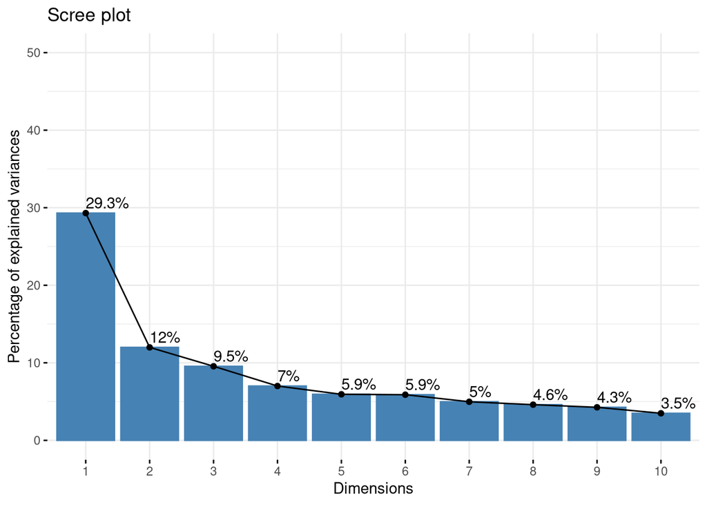

```r
# Visualize the PCA results
fviz_eig(pca, addlabels = TRUE, ylim = c(0, 50))
```

### BiPlot

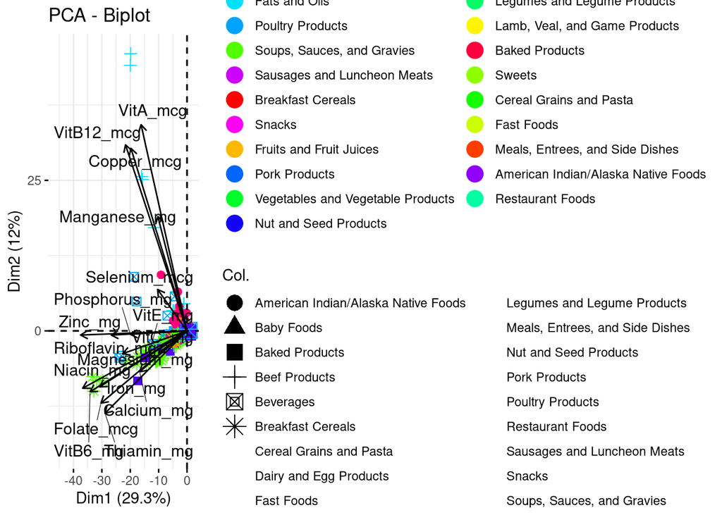

```r
col_unique <- as.character(data$FoodGroup)

color_values <- setNames(rainbow(length(unique(col_unique))), unique(col_unique))


fviz_pca_biplot(pca, geom.ind = "point", pointsize = 2.5 , col.var = "black" ,
                col.ind =col_unique ,  repel = TRUE)+
  scale_color_manual(name = "Food Groups", labels = unique(col_unique), values = color_values)
```

### Visualization

Now let’s look at which food groups are highest in each component

```r
pca_results <- as.data.frame(pca$x)
pca_results$FoodGroup <- data$FoodGroup

plot_top_foodgroups <- function(pca_results, component, n = 10) {
  top_foodgroups <- pca_results %>%
    arrange(desc(!!sym(component))) %>%
    slice(1:n) %>%
    count(FoodGroup, sort = TRUE)

  ggplot(top_foodgroups, aes(x = reorder(FoodGroup, n), y = n)) +
    geom_bar(stat = "identity") +
    coord_flip() +
    labs(title = paste("Top Food Groups for", component),
         x = "Food Group", y = "Count")
}
```

### Creating dataset with pricipal components

- Creating dataset with 7 PCs

```r
pca_df <- as.data.frame(pca$x[, 1:7])
pca_df <- rownames_to_column(pca_df, var = "ID")
names(pca_df)
```

```
[1] "ID"  "PC1" "PC2" "PC3" "PC4" "PC5" "PC6" "PC7"
```

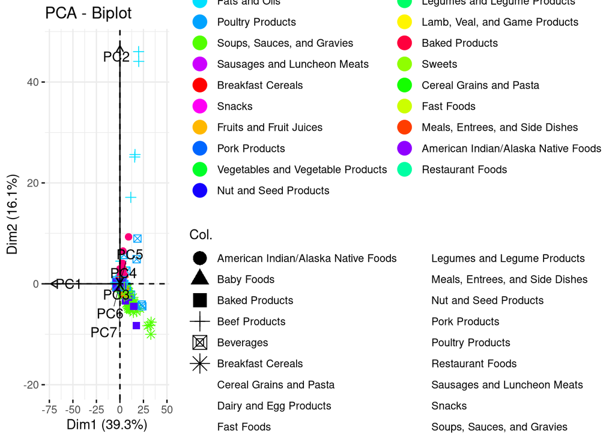

```r
pca_new <- prcomp(pca_df[, 2:8])
#cor(pca_df[, 2:8])
#mean(cor(pca_df[, 2:8]))
fviz_pca_biplot(pca_new, geom.ind = "point", pointsize = 2.5 , col.var = "black" ,
                col.ind =col_unique ,  repel = TRUE)+
  scale_color_manual(name = "Food Groups", labels = unique(col_unique), values = color_values)
```

### Analysis of PCA Components

PC1

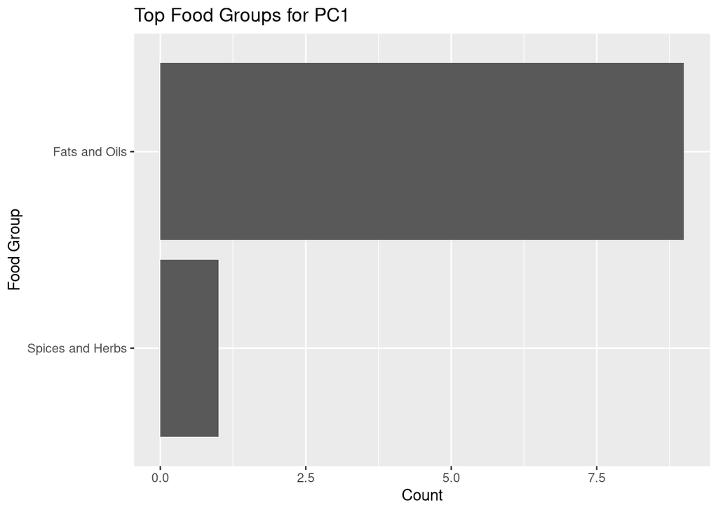

```r
  component <- paste0("PC", 1)
  print(plot_top_foodgroups(pca_results, component))
```

PC2

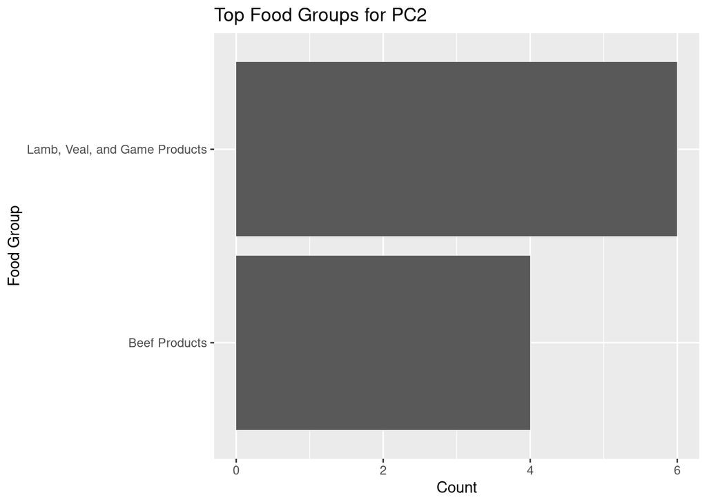

```r
  component <- paste0("PC", 2)
  print(plot_top_foodgroups(pca_results, component))
```

PC3

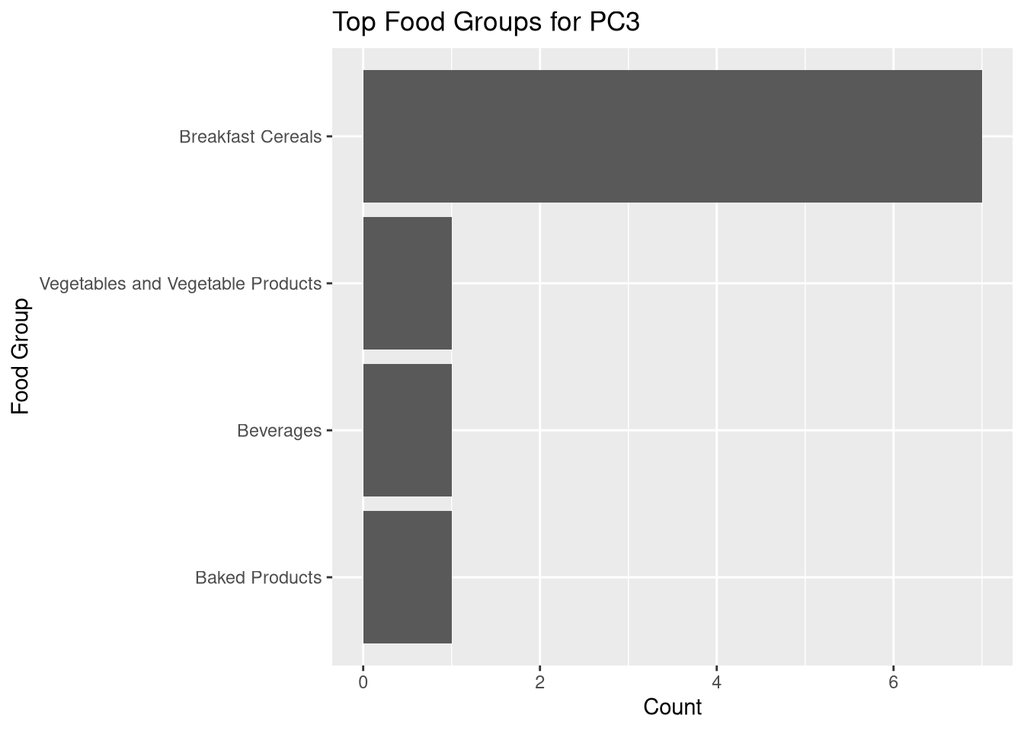

```r
  component <- paste0("PC", 3)
  print(plot_top_foodgroups(pca_results, component))
```

PC4

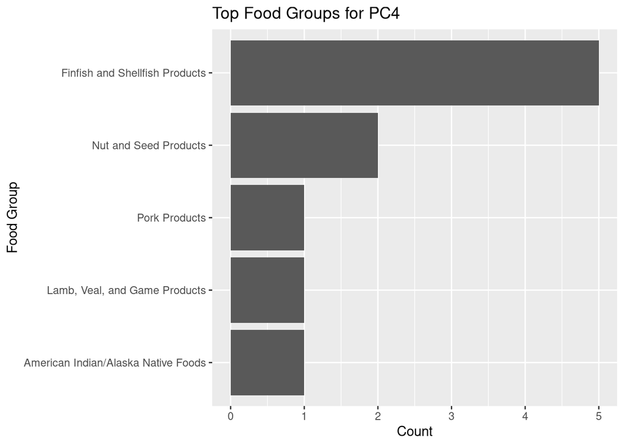

```r
  component <- paste0("PC", 4)
  print(plot_top_foodgroups(pca_results, component))
```

PC5

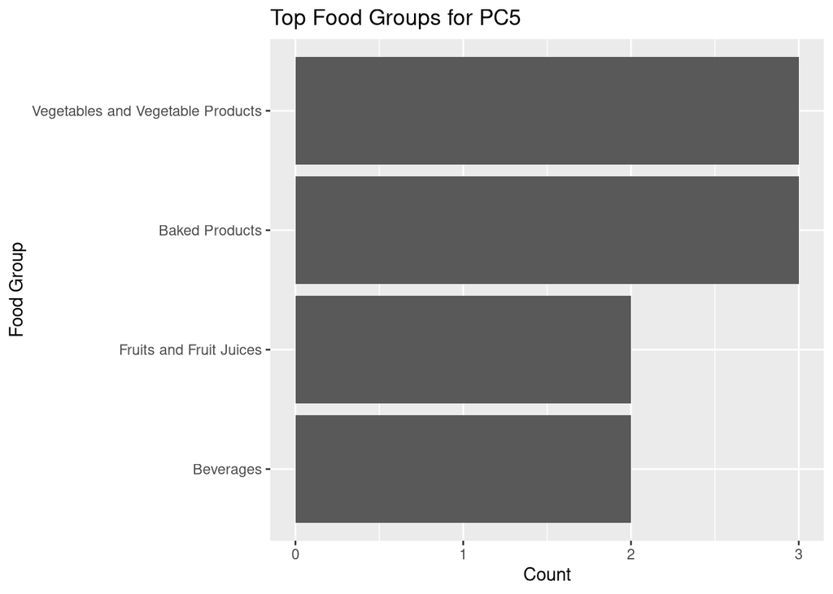

```r
  component <- paste0("PC", 5)
  print(plot_top_foodgroups(pca_results, component))
```

Foods that are high in: VitC and Manganese

Low in: Niacin_mg Riboflavin_mg

```r
vects <- pca$rotation[, 1:5]
component_one <- vects[, 1]
print(sort(component_one, decreasing = TRUE))
```

```
      VitC_mg  Manganese_mg  Selenium_mcg       VitE_mg      VitA_mcg
  -0.09963052   -0.10192369   -0.10276532   -0.13512856   -0.16066077
   Calcium_mg    Copper_mcg Phosphorus_mg    VitB12_mcg  Magnesium_mg
  -0.16572924   -0.19601027   -0.19827855   -0.21508300   -0.22483295
      Zinc_mg    Thiamin_mg    Folate_mcg       Iron_mg      VitB6_mg
  -0.26492115   -0.28686644   -0.30102839   -0.30556015   -0.33893986
    Niacin_mg Riboflavin_mg
  -0.36489500   -0.37222654
```

Foods that are high in: VitA and VitB12

Low in: Folate and Thiamin

```r
component_two <- vects[, 2]
print(sort(component_two, decreasing = TRUE))
```

```
     VitA_mcg    VitB12_mcg    Copper_mcg  Manganese_mg  Selenium_mcg
  0.531120309   0.479179996   0.470112218   0.294594686   0.106758455
Phosphorus_mg Riboflavin_mg       Zinc_mg       VitC_mg  Magnesium_mg
 -0.008667522  -0.010622067  -0.010766576  -0.057077984  -0.058535266
      VitE_mg    Calcium_mg       Iron_mg     Niacin_mg      VitB6_mg
 -0.064786345  -0.105356349  -0.144165721  -0.147649442  -0.156718701
   Folate_mcg    Thiamin_mg
 -0.186077273  -0.212258949
```

## Summary of Test results

Dimensionality Reduction:

- By reducing the dataset to a few principal components, this helps in simplifying the dataset while retaining most of the important information.

Top Contributing Food Groups:

- The bar plots for each of the first five principal components indicate which food groups are most influential in each component.
- This helps in understanding the underlying structure of the data and identifying patterns or groups of foods that are similar in their nutritional profiles.

## Conclusion

Principal Component Analysis (PCA) is an invaluable tool in the realm of data analysis.

Through its mathematical foundation in linear algebra, PCA transforms high-dimensional data into a set of orthogonal principal components, each representing a direction of maximum variance within the dataset. (Altman and Krzywinski 2018)

This transformation not only simplifies data complexity but also facilitates improved interpretation and visualization, making PCA a crucial technique in different fields.

Despite its strengths, PCA is not without limitations. The linear nature of PCA may not capture complex, non-linear relationships within data, and the interpretation of principal components can sometimes be challenging.

PCA remains a fundamental technique in multivariate analysis, providing essential insights into data structure and aiding in the development of robust analytical models. As the volume and complexity of data continue to grow, PCA’s role in facilitating efficient data analysis and decision-making will be more critical .

## References

Altman, Naomi, and Martin Krzywinski. 2018. “The Curse(s) of Dimensionality.” *Nature Methods* 15 (6): 397–400. https://doi.org/10.1038/s41592-018-0019-x.

Bro, Rasmus, and Age K Smilde. 2014. “Principal Component Analysis.” *Analytical Methods* 6 (9): 2812–31. https://doi.org/10.1039/C3AY41907J.

Jauregui, J. 2017. “Principal Component Analysis with Linear Algebra.” *International Journal of Educational Methodology*. https://doi.org/10.12973/ijem.3.2.75.

Johnson, Richard, and Dean Wichern. 2023. *Applied Multivariate Statistical Analysis*. Pearson.

Sidharth Prasad, M. 2017. “Multivariate Statistical Data Analysis- Principal Component Analysis (PCA).” *Department of Animal Genetics and Breeding*. https://doi.org/10.5455/ijlr.20170415115235.